# Assigment - Naive Bayes DIY

A. ten Napel - Author

A.Haijkers - Reviewer

24 March, 2022

```r
library(tidyverse)
library(tm)
library(caret)
library(wordcloud)
library(e1071)
```

```r
memory.limit(size=100000)
```

```
[1] 1e+05
```

## Business Understanding

#### De data bestaat uit een set artikelen waar mee met behulp van Naive Base bepaald dient te worden of een artikel geclassificeerd moet worden als nieuws of als nepnieuws.

## Data Understanding

```r
url <- "https://raw.githubusercontent.com/HAN-M3DM-Data-Mining/data-mining-s2y2122-Aronnpl/master/datasets/NB-fakenews.csv"
#rawDF <- read_csv(url)
#head(rawDF)
RawDF<- read_csv(url)
rawDF<-slice_head(RawDF,n=7500)
#although not necissary, I used the above code to make the sample size smaller when checking for errors, saving me a #lot of time where the computer would calculate only to return an error.
```

#### De data bestaat uit 5 variabelen en 20800 artikelen (rijen).

#### Om de data goed te interpreteren is het van belang om te begrijpen wat de verschillende kolommen inhouden.

##### id : unieke id voor een nieuwsartikel

##### titel : de titel van een nieuwsartikel

##### auteur : auteur van het nieuwsartikel

##### tekst : de tekst van het artikel; zou onvolledig kunnen zijn

##### label : een label dat het artikel als mogelijk onbetrouwbaar markeert

##### 1: onbetrouwbaar

##### 0: betrouwbaar

#### Om vooraf vast een inzicht te geven in de gegevens wordt eerst een verdeling gegeven. Zoals je kunt zien is dit vrij goed verdeeld.

```r
#Tel.bezetting <- table(rawDF$type)
#we want to see the divide in trustworthy and untrustworthy news sources meaning we have to look at the label
Tel.bezetting <- table(rawDF$label)
Tel.bezetting
```

```
   0    1
3755 3745
```

#### Aangezien de laatste kolom het label bevat zal deze gewijzigd moeten worden naar het type ‘factor’

```r
#rawDF$type <- factor(rawDF$type)
#again, we want to turn the variable label into a factor
rawDF$label <- factor(rawDF$label)
head(rawDF, 5)
```

| id | title | author | text | label |
| --- | --- | --- | --- | --- |
| 0 | House Dem Aide: We Didn\222t Even See Comey\222s Letter Until Jason Chaffetz Tweeted It | Darrell Lucus | House Dem Aide: We Didn\222t Even See Comey\222s Letter Until Jason Chaffetz Tweeted It By Darrell Lucus on October 30, 2016 Subscribe Jason Chaffetz on the stump in American Fork, Utah ( image courte… | 1 |
| 1 | FLYNN: Hillary Clinton, Big Woman on Campus - Breitbart | Daniel J. Flynn | Ever get the feeling your life circles the roundabout rather than heads in a straight line toward the intended destination? [Hillary Clinton remains the big woman on campus in leafy, liberal Wellesley… | 0 |
| 2 | Why the Truth Might Get You Fired | Consortiumnews.com | Why the Truth Might Get You Fired October 29, 2016 \nThe tension between intelligence analysts and political policymakers has always been between honest assessments and desired results, with the latte… | 1 |
| 3 | 15 Civilians Killed In Single US Airstrike Have Been Identified | Jessica Purkiss | Videos 15 Civilians Killed In Single US Airstrike Have Been Identified The rate at which civilians are being killed by American airstrikes in Afghanistan is now higher than it was in 2014 when the US … | 1 |
| 4 | Iranian woman jailed for fictional unpublished story about woman stoned to death for adultery | Howard Portnoy | Print \nAn Iranian woman has been sentenced to six years in prison after Iran\222s Revolutionary Guard searched her home and found a notebook that contained a fictional story she\222d written about a … | 1 |

#### Het principe van Naive Base werkt op basis van gebruike woorden en de hoeveelheid hiervan. Om een eerste visuele indruk op te doen wordt er van zowel nieuws als nepniews een zogenoemde ‘wordcloud’ gemaakt. De tekst in het groen staat hierbij voor het ‘nieuws’ en de tekst in het oranje voor het ‘nepnieuws’.

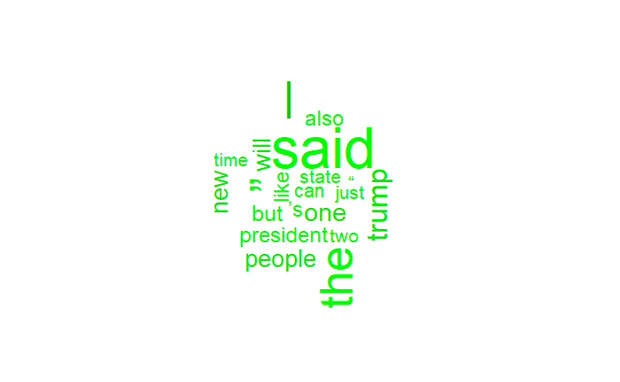

```r
#nieuws <- rawDF %>% filter(label == "1")
#nepnieuws <- rawDF %>% filter(label == "0")
#it is important we select the right files, with 0 being the real news and 1 being untrustworthy
nieuws <- rawDF %>% filter(label == "0")
nepnieuws <- rawDF %>% filter(label == "1")

wordcloud(nieuws$text, max.words = 20, scale = c(4, 0.8), colors= c("green1","green2","green3","green"))
```

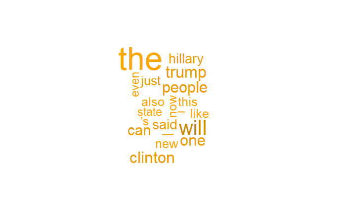

```r
wordcloud(nepnieuws$text, max.words = 20, scale = c(4, 0.8), colors= c("orange1","orange2","orange3","orange"))
```

## Data Preparation

#### Nu we weten wat de data inhoud kunnen we de data gaan opschonen en bruikbaar maken voor analyse.

#### Eerst moeten we een corpus maken, dat verwijst naar een verzameling artikelen.

```r
#rawCorpus <- Corpus(VectorSource(rawDF$title))
#natrually we want to base our naive bays on the body of the text, not the title
rawCorpus <- Corpus(VectorSource(rawDF$text))
inspect(rawCorpus[1:2])
```

```
<<SimpleCorpus>>
Metadata:  corpus specific: 1, document level (indexed): 0
Content:  documents: 2

[1] House Dem Aide: We Didn’t Even See Comey’s Letter Until Jason Chaffetz Tweeted It By Darrell Lucus on October 30, 2016 Subscribe Jason Chaffetz on the stump in American Fork, Utah ( image courtesy Michael Jolley, available under a Creative Commons-BY license) \nWith apologies to Keith Olbermann,…
[2] Ever get the feeling your life circles the roundabout rather than heads in a straight line toward the intended destination? [Hillary Clinton remains the big woman on campus in leafy, liberal Wellesley, Massachusetts. Everywhere else votes her most likely to don her inauguration dress for the rem…
```

#### Aangezien deze artikelen veel inrelevante informatie bevatten welke de analyse ongewenst kan beinvloeden worden de hoofdletters omgezet naar kleine letters en worden de nummers, stopwoorden, leestekens en witruimtes eruit gefilterd.

```r
cleanCorpus <- rawCorpus %>% tm_map(tolower) %>% tm_map(removeNumbers) %>%
  tm_map(tolower) %>% tm_map(removeWords, stopwords()) %>% tm_map(removePunctuation) %>% tm_map(stripWhitespace)
tibble(Raw = rawCorpus$content[1:3], Clean = cleanCorpus$content[1:3])
```

| Raw | Clean |
| --- | --- |
| House Dem Aide: We Didn\222t Even See Comey\222s Letter Until Jason Chaffetz Tweeted It By Darrell Lucus on October 30, 2016 Subscribe Jason Chaffetz on the stump in American Fork, Utah ( image courte… | house dem aide didn\222t even see comey\222s letter jason chaffetz tweeted darrell lucus october subscribe jason chaffetz stump american fork utah image courtesy michael jolley available creative comm… |
| Ever get the feeling your life circles the roundabout rather than heads in a straight line toward the intended destination? [Hillary Clinton remains the big woman on campus in leafy, liberal Wellesley… | ever get feeling life circles roundabout rather heads straight line toward intended destination hillary clinton remains big woman campus leafy liberal wellesley massachusetts everywhere else votes lik… |
| Why the Truth Might Get You Fired October 29, 2016 \nThe tension between intelligence analysts and political policymakers has always been between honest assessments and desired results, with the latte… | truth might get fired october tension intelligence analysts political policymakers always honest assessments desired results latter often overwhelming former iraq war writes lawrence davidson lawrence… |

#### Laten we nu een matrix maken van de artikelen waarbij elke kolom een woord vertegenwoordigd en elke rij een artikel.

```r
cleanDNB <- cleanCorpus %>% DocumentTermMatrix
#inspect(cleanCorpus)
inspect(cleanDNB)
```

```
<<DocumentTermMatrix (documents: 7500, terms: 139521)>>
Non-/sparse entries: 2090071/1044317429
Sparsity           : 100%
Maximal term length: 242
Weighting          : term frequency (tf)
Sample             :
      Terms
Docs     “ ’s   —  ” new one people said trump will
  1684   7 13   0  4  10  26     40    5     1   57
  2113  24 28   5  4   1  30     64   13     1   29
  2735  40 62   4 20  17  74     53   17    63  154
  2737  34 14 213 43  27  20     21   17    53   88
  465  122  7   2 31   7  20     14    5     0   16
  503    2 13   0  1  14  22     30   33     4   46
  5093  13 82   3  3  19  59    105   10     1   61
  5458  16 25   1  8   6  25     36   12    36   75
  7467  22 50   3  3  17  31     60    9     0   27
  7475  47 29   0 13   5  58     48   19     0   64
```

```r
#freqw <- cleanDNB %>% findFreqTerms(10)
#although technically not an error, since it would make the program unbearably slow/nonfunctional the number of terms #need to be reduced
freqw <- cleanDNB %>% findFreqTerms(30)
cleanDNBF <-  DocumentTermMatrix(cleanCorpus, list(dictionary = freqw))
inspect(cleanDNBF)
```

```
<<DocumentTermMatrix (documents: 7500, terms: 11160)>>
Non-/sparse entries: 1725111/81974889
Sparsity           : 98%
Maximal term length: 154
Weighting          : term frequency (tf)
Sample             :
      Terms
Docs     “ ’s   —  ” new one people said trump will
  1684   7 13   0  4  10  26     40    5     1   57
  2735  40 62   4 20  17  74     53   17    63  154
  2737  34 14 213 43  27  20     21   17    53   88
  465  122  7   2 31   7  20     14    5     0   16
  503    2 13   0  1  14  22     30   33     4   46
  5093  13 82   3  3  19  59    105   10     1   61
  5458  16 25   1  8   6  25     36   12    36   75
  6293  20 28   1  6   6  26     45    5     0   39
  7467  22 50   3  3  17  31     60    9     0   27
  7475  47 29   0 13   5  58     48   19     0   64
```

#### Nu de data voorbereid is zullen er trainings- en testsets gemaakt moeten worden om het model te kunnen testen. Met behulp van de createDataPartition()-functie kan gemakkelijk een verdeling worden gemaakt, in onderstaande is voor een verdeling gekozen van 70 tot 30.

```r
set.seed(2202)
#trainIndex <- createDataPartition(rawDF$label, p = .30,
#this would create a 30/70 split, not a 70/30
trainIndex <- createDataPartition(rawDF$label, p = .70,
                                  list = FALSE,
                                  times = 1)
head(trainIndex)
```

```
     Resample1
[1,]         1
[2,]         2
[3,]         4
[4,]         6
[5,]         7
[6,]         9
```

```r
trainDF <- rawDF[trainIndex, ]
testDF <- rawDF[-trainIndex, ]
trainDTM <- cleanDNBF[trainIndex, ]
testDTM <- cleanDNBF[-trainIndex, ]
```

#### De laatste stap voordat we kunnen modelleren is het omzetten van getallen hoevaak een woord voorkomt naar een factor welke aangeeft of het woord uberhäupt voorkomt. Dit is benodigd vanwege de categorische kenmerken.

```r
convert_counts <- function(x) {
  x <- ifelse(x > 0, 1, 0) %>% factor(levels = c(0,1), labels = c("No", "Yes"))
}

nColsDTM <- dim(trainDTM)[2]
trainDTM <- apply(trainDTM, MARGIN = 2, convert_counts)
testDTM <- apply(testDTM, MARGIN = 2, convert_counts)

head(trainDTM[,1:10])
```

```
    Terms
Docs abusive according acting actually advance agency aide  already also  american
   1 "Yes"   "Yes"     "Yes"  "Yes"    "Yes"   "Yes"  "Yes" "Yes"   "Yes" "Yes"
   2 "No"    "No"      "No"   "No"     "No"    "No"   "No"  "No"    "No"  "Yes"
   4 "No"    "No"      "No"   "No"     "No"    "No"   "No"  "No"    "No"  "Yes"
   6 "No"    "No"      "No"   "No"     "No"    "No"   "No"  "No"    "Yes" "No"
   7 "No"    "No"      "No"   "No"     "No"    "No"   "No"  "No"    "Yes" "No"
   9 "No"    "No"      "No"   "No"     "Yes"   "Yes"  "No"  "No"    "Yes" "Yes"
```

## Modeling

#### Inmiddels is alle data goed genoeg om te kunnen modelleren. We maken hierbij eerst het model aan op basis van de traindata.

```r
#nbayesModel <-  naiveBayes(trainDTM, trainDF$title, laplace = 1)
#again, the variable we are looking for it label, not title
nbayesModel <-  naiveBayes(trainDTM, trainDF$label, laplace = 1)
```

#### Vervolgens kunnen we het model zelf testen.

```r
predVec <- predict(nbayesModel, testDTM)
#confusionMatrix(predVec, testDF$label, positive = "1", dnn = c("Prediction", "True"))
#we are looking for reliable news which is indicated with a 0, not a 1
confusionMatrix(predVec, testDF$label, positive = "0", dnn = c("Prediction", "True"))
```

```
Confusion Matrix and Statistics

          True
Prediction   0   1
         0 731 203
         1 395 920

               Accuracy : 0.7341
                 95% CI : (0.7153, 0.7523)
    No Information Rate : 0.5007
    P-Value [Acc > NIR] : < 2.2e-16

                  Kappa : 0.4683

 Mcnemar's Test P-Value : 5.693e-15

            Sensitivity : 0.6492
            Specificity : 0.8192
         Pos Pred Value : 0.7827
         Neg Pred Value : 0.6996
             Prevalence : 0.5007
         Detection Rate : 0.3250
   Detection Prevalence : 0.4153
      Balanced Accuracy : 0.7342

       'Positive' Class : 0
```

## Evaluation and Deployment

You could improve it by doing as was said above and select words that occur ten times instead of 30. Although this would be more taxing on the computer running the program, it would give the computer a higher sample size of words to calculate with, giving us more accurate predictions on whether the article is reliable or not.